# NYPD Shooting Incident Data Analysis

2023-09-27

## Download Links

You can download the reproducible .RMD document from which this knitted HTML was generated from the links below.

- DTSA5301_NYDP_Shooting.Rmd ([Raw](https://raw.githubusercontent.com/estersstirrer/DTSA5301/main/DTSA5301_NYDP_Shooting.Rmd))
- DTSA5301_NYDP_Shooting.html ([Raw](https://raw.githubusercontent.com/estersstirrer/DTSA5301/main/DTSA5301_NYDP_Shooting.html))

If your browser does not handle the above links well, please visit [my github.com repository](https://github.com/estersstirrer/DTSA5301/) to find and grab [the RMD file](https://github.com/estersstirrer/DTSA5301/blob/main/DTSA5301_NYDP_Shooting.Rmd) from there.

## Abstract

Although the NYPD Shooting Incident Data revealed a significant increase beginning in May 2020 – a rise potentially attributed to the COVID-19 pandemic, the BLM Movement, or both – no discernible factors have been identified through this analysis with available data on victims and perpetrators. A more comprehensive analysis incorporating additional data is necessary to determine the underlying mechanism of this spike.

## Library Dependencies

For this project, I need only basic libraries, `'tidyverse'` and `'lubridate'`, just as usual.

```r
library(tidyverse)
library(lubridate)
```

## Data Preparation

### Importing NYPD Shooting Incident Data (Historic)

This publicly available government-provided data lists all shooting incidents in New York from **2006** to the end of **2022**. Each record represents a shooting incident in New York City and includes information about the incident, location, and time of occurrence. It also provides information related to suspect and victim demographics.

We should import the data directly from [the U.S. Government’s Open Data Official Site](https://catalog.data.gov/dataset) in order to maintain this report **reproducible**.

```r
csv_data <- read.csv("https://data.cityofnewyork.us/api/views/833y-fsy8/rows.csv?accessType=DOWNLOAD")
```

In this report, I keep this NYPD Shooting Incident Data in a `tibble` object for efficient manipulation.

```r
nypd_all <- tibble(csv_data)
nypd_all
```

```
## # A tibble: 27,312 × 21
##    INCIDENT_KEY OCCUR_DATE OCCUR_TIME BORO     LOC_OF_OCCUR_DESC PRECINCT
##           <int> <chr>      <chr>      <chr>    <chr>                <int>
##  1    228798151 05/27/2021 21:30:00   QUEENS   ""                     105
##  2    137471050 06/27/2014 17:40:00   BRONX    ""                      40
##  3    147998800 11/21/2015 03:56:00   QUEENS   ""                     108
##  4    146837977 10/09/2015 18:30:00   BRONX    ""                      44
##  5     58921844 02/19/2009 22:58:00   BRONX    ""                      47
##  6    219559682 10/21/2020 21:36:00   BROOKLYN ""                      81
##  7     85295722 06/17/2012 22:47:00   QUEENS   ""                     114
##  8     71662474 03/08/2010 19:41:00   BROOKLYN ""                      81
##  9     83002139 02/05/2012 05:45:00   QUEENS   ""                     105
## 10     86437261 08/26/2012 01:10:00   QUEENS   ""                     101
## # ℹ 27,302 more rows
## # ℹ 15 more variables: JURISDICTION_CODE <int>, LOC_CLASSFCTN_DESC <chr>,
## #   LOCATION_DESC <chr>, STATISTICAL_MURDER_FLAG <chr>, PERP_AGE_GROUP <chr>,
## #   PERP_SEX <chr>, PERP_RACE <chr>, VIC_AGE_GROUP <chr>, VIC_SEX <chr>,
## #   VIC_RACE <chr>, X_COORD_CD <dbl>, Y_COORD_CD <dbl>, Latitude <dbl>,
## #   Longitude <dbl>, Lon_Lat <chr>
```

### Tidying and Transforming

To demonstrate how we can complete all steps in the data science process, I will tidy up and transform this NYPD Shooting Incident Data step-by-step. Let’s see how it goes.

#### Narrowing Down

First, since I will focus only on the information in the following fields in this paper, I will remove the others.

- `OCCUR_DATE` - Exact date of the shooting incident
- `BORO` - Borough where the shooting incident occurred
- `STATISTICAL_MURDER_FLAG` - Shooting resulted in the victim’s death which would be counted as a murder
- `VIC_SEX` - Victim’s sex description
- `VIC_RACE` - Victim’s race description
- `PERP_SEX` - Perpetrator’s sex description
- `PERP_RACE` - Perpetrator’s race description

```r
nypd_selected <- nypd_all %>%
  select(OCCUR_DATE,
         BORO,
         STATISTICAL_MURDER_FLAG,
         VIC_SEX,
         VIC_RACE,
         PERP_SEX,
         PERP_RACE)
nypd_selected
```

```
## # A tibble: 27,312 × 7
##    OCCUR_DATE BORO    STATISTICAL_MURDER_F…¹ VIC_SEX VIC_RACE PERP_SEX PERP_RACE
##    <chr>      <chr>   <chr>                  <chr>   <chr>    <chr>    <chr>
##  1 05/27/2021 QUEENS  false                  M       BLACK    ""       ""
##  2 06/27/2014 BRONX   false                  M       BLACK    ""       ""
##  3 11/21/2015 QUEENS  true                   M       WHITE    ""       ""
##  4 10/09/2015 BRONX   false                  M       WHITE H… ""       ""
##  5 02/19/2009 BRONX   true                   M       BLACK    "M"      "BLACK"
##  6 10/21/2020 BROOKL… true                   M       BLACK    ""       ""
##  7 06/17/2012 QUEENS  false                  M       BLACK    ""       ""
##  8 03/08/2010 BROOKL… true                   M       BLACK    ""       ""
##  9 02/05/2012 QUEENS  false                  M       BLACK    ""       ""
## 10 08/26/2012 QUEENS  false                  M       BLACK    "M"      "BLACK"
## # ℹ 27,302 more rows
## # ℹ abbreviated name: ¹STATISTICAL_MURDER_FLAG
```

#### Renaming

It’s my preference, but I redefine the column names using camel case notation to make it easier to type and handle.

```r
nypd_renamed <- nypd_selected %>%
  rename(Date = OCCUR_DATE,
         Borough = BORO,
         Murder = STATISTICAL_MURDER_FLAG,
         VicSex = VIC_SEX,
         VicRace = VIC_RACE,
         PerpSex = PERP_SEX,
         PerpRace = PERP_RACE)
nypd_renamed
```

```
## # A tibble: 27,312 × 7
##    Date       Borough  Murder VicSex VicRace        PerpSex PerpRace
##    <chr>      <chr>    <chr>  <chr>  <chr>          <chr>   <chr>
##  1 05/27/2021 QUEENS   false  M      BLACK          ""      ""
##  2 06/27/2014 BRONX    false  M      BLACK          ""      ""
##  3 11/21/2015 QUEENS   true   M      WHITE          ""      ""
##  4 10/09/2015 BRONX    false  M      WHITE HISPANIC ""      ""
##  5 02/19/2009 BRONX    true   M      BLACK          "M"     "BLACK"
##  6 10/21/2020 BROOKLYN true   M      BLACK          ""      ""
##  7 06/17/2012 QUEENS   false  M      BLACK          ""      ""
##  8 03/08/2010 BROOKLYN true   M      BLACK          ""      ""
##  9 02/05/2012 QUEENS   false  M      BLACK          ""      ""
## 10 08/26/2012 QUEENS   false  M      BLACK          "M"     "BLACK"
## # ℹ 27,302 more rows
```

#### Cleaning

Attribute information for many victims and perpetrators is not standardized. The values, especially the missing values, are not recorded consistently; there are just empty strings, `NA`, or listed as `"UNKNOWN"` or `"(null)"`. Therefore, it is necessary to normalize the information before getting into the data analysis in this report.

```r
nypd_cleaned <- nypd_renamed %>%
  mutate(Borough = case_when(Borough == "" ~ "Unknown",
                             is.na(Borough) ~ "Unknown",
                             TRUE ~ Borough),
         VicRace = case_when(VicRace == "" ~ "Unknown",
                             tolower(VicRace) == "(null)" ~ "Unknown",
                             tolower(VicRace) == "unknown" ~ "Unknown",
                             is.na(VicRace) | is.null(VicRace) ~ "Unknown",
                             TRUE ~ VicRace),
         VicSex = case_when(VicSex == "M" ~ "Male",
                            VicSex == "F" ~ "Female",
                            is.na(VicSex) | is.null(VicSex) ~ "Unknown",
                            TRUE ~ "Unknown"),
         PerpRace = case_when(PerpRace == "" ~ "Unknown",
                             tolower(PerpRace) == "(null)" ~ "Unknown",
                             tolower(PerpRace) == "unknown" ~ "Unknown",
                             is.na(PerpRace) | is.null(PerpRace) ~ "Unknown",
                             TRUE ~ PerpRace),
         PerpSex = case_when(PerpSex == "M" ~ "Male",
                             PerpSex == "F" ~ "Female",
                             is.na(PerpSex) | is.null(PerpSex) ~ "Unknown",
                             TRUE ~ "Unknown"))
nypd_cleaned
```

```
## # A tibble: 27,312 × 7
##    Date       Borough  Murder VicSex VicRace        PerpSex PerpRace
##    <chr>      <chr>    <chr>  <chr>  <chr>          <chr>   <chr>
##  1 05/27/2021 QUEENS   false  Male   BLACK          Unknown Unknown
##  2 06/27/2014 BRONX    false  Male   BLACK          Unknown Unknown
##  3 11/21/2015 QUEENS   true   Male   WHITE          Unknown Unknown
##  4 10/09/2015 BRONX    false  Male   WHITE HISPANIC Unknown Unknown
##  5 02/19/2009 BRONX    true   Male   BLACK          Male    BLACK
##  6 10/21/2020 BROOKLYN true   Male   BLACK          Unknown Unknown
##  7 06/17/2012 QUEENS   false  Male   BLACK          Unknown Unknown
##  8 03/08/2010 BROOKLYN true   Male   BLACK          Unknown Unknown
##  9 02/05/2012 QUEENS   false  Male   BLACK          Unknown Unknown
## 10 08/26/2012 QUEENS   false  Male   BLACK          Male    BLACK
## # ℹ 27,302 more rows
```

#### Type Casting

We need to have the `Date` column as a type of `date` and the `Murder` column as `logical`, as we currently have both as `character`.

```r
nypd_typed <- nypd_cleaned %>%
  mutate(Date = mdy(Date),
         Murder = (Murder == "true"))
nypd_typed
```

```
## # A tibble: 27,312 × 7
##    Date       Borough  Murder VicSex VicRace        PerpSex PerpRace
##    <date>     <chr>    <lgl>  <chr>  <chr>          <chr>   <chr>
##  1 2021-05-27 QUEENS   FALSE  Male   BLACK          Unknown Unknown
##  2 2014-06-27 BRONX    FALSE  Male   BLACK          Unknown Unknown
##  3 2015-11-21 QUEENS   TRUE   Male   WHITE          Unknown Unknown
##  4 2015-10-09 BRONX    FALSE  Male   WHITE HISPANIC Unknown Unknown
##  5 2009-02-19 BRONX    TRUE   Male   BLACK          Male    BLACK
##  6 2020-10-21 BROOKLYN TRUE   Male   BLACK          Unknown Unknown
##  7 2012-06-17 QUEENS   FALSE  Male   BLACK          Unknown Unknown
##  8 2010-03-08 BROOKLYN TRUE   Male   BLACK          Unknown Unknown
##  9 2012-02-05 QUEENS   FALSE  Male   BLACK          Unknown Unknown
## 10 2012-08-26 QUEENS   FALSE  Male   BLACK          Male    BLACK
## # ℹ 27,302 more rows
```

#### Sorting

As this is a time series data, I want it sorted in time-ascending order.

```r
nypd_sorted <- arrange(nypd_typed, Date, Borough)
```

Finally, we have got the shooting data tidied up entirely as follows:

```
## # A tibble: 27,312 × 7
##    Date       Borough   Murder VicSex VicRace        PerpSex PerpRace
##    <date>     <chr>     <lgl>  <chr>  <chr>          <chr>   <chr>
##  1 2006-01-01 BRONX     FALSE  Male   WHITE HISPANIC Male    WHITE HISPANIC
##  2 2006-01-01 BRONX     FALSE  Male   BLACK          Male    BLACK
##  3 2006-01-01 BROOKLYN  TRUE   Male   BLACK          Unknown Unknown
##  4 2006-01-01 BROOKLYN  FALSE  Male   BLACK          Unknown Unknown
##  5 2006-01-01 MANHATTAN TRUE   Male   BLACK          Male    BLACK
##  6 2006-01-01 QUEENS    TRUE   Male   BLACK          Male    BLACK
##  7 2006-01-01 QUEENS    FALSE  Male   BLACK          Male    BLACK
##  8 2006-01-01 QUEENS    TRUE   Male   BLACK          Male    BLACK
##  9 2006-01-02 BROOKLYN  TRUE   Male   BLACK          Unknown Unknown
## 10 2006-01-02 BROOKLYN  FALSE  Male   BLACK          Male    BLACK
## # ℹ 27,302 more rows
```

## Analyzing Data with Visualization

### Visualization of the Number of Shootings in New York

First, let’s visualize the number of shootings by plotting them over time every month and see what we get.

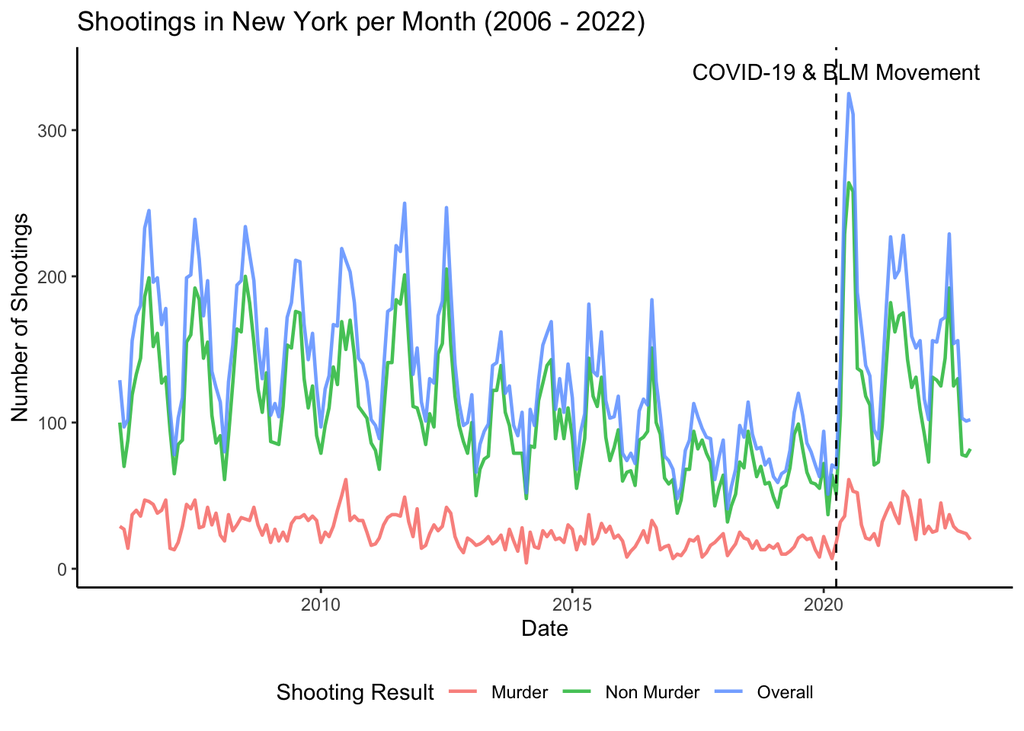

```r
nypd_sorted %>%
  mutate(Month = floor_date(Date, "month")) %>%
  group_by(Month) %>%
  summarize(Overall = n(),
            Murder = sum(Murder),
            "Non Murder" = (Overall - Murder)) %>%
  pivot_longer(cols = c(Overall, Murder, "Non Murder"),
               names_to = "Kind",
               values_to = "Count") %>%
  ggplot(aes(x = Month, y = Count, color = Kind)) +
  geom_line(linewidth = 0.8, alpha = 0.8) +
  geom_vline(xintercept = ymd('2020-04-01'), linetype = "dashed") +
  annotate(geom="text", x = ymd('2020-04-01'), y = 340, label="COVID-19 & BLM Movement") +
  labs(title = "Shootings in New York per Month (2006 - 2022)",
       x = "Date",
       y = "Number of Shootings",
       color = "Shooting Result") +
  theme_classic() +
  theme(legend.position = "bottom")
```

### Analyzing the Number of Shootings in New York

#### Overall Trends

As illustrated in the graph above, there has been a notable increase in shootings since May 2020, marked by a sustained rise in incidents.

From a macroscopic viewpoint, this escalation can potentially be ascribed to the onset of the COVID-19 pandemic, the BLM Movement, or both, emerging around May 2020 in the United States. However, the specific factors within these events that may have directly contributed to the increase in shooting incidents remain indistinct in this visualization. A more detailed factor analysis is essential to pinpoint the precise catalysts for this trend.

#### Shooting Victims and Perpetrators by Race, and Sex

To find more detailed changes in the differences before and after the pandemic, I will plot the shootings by victims’ and perpetrators’ attributes (sex, race) one by one, separately.

##### Plotting By Race

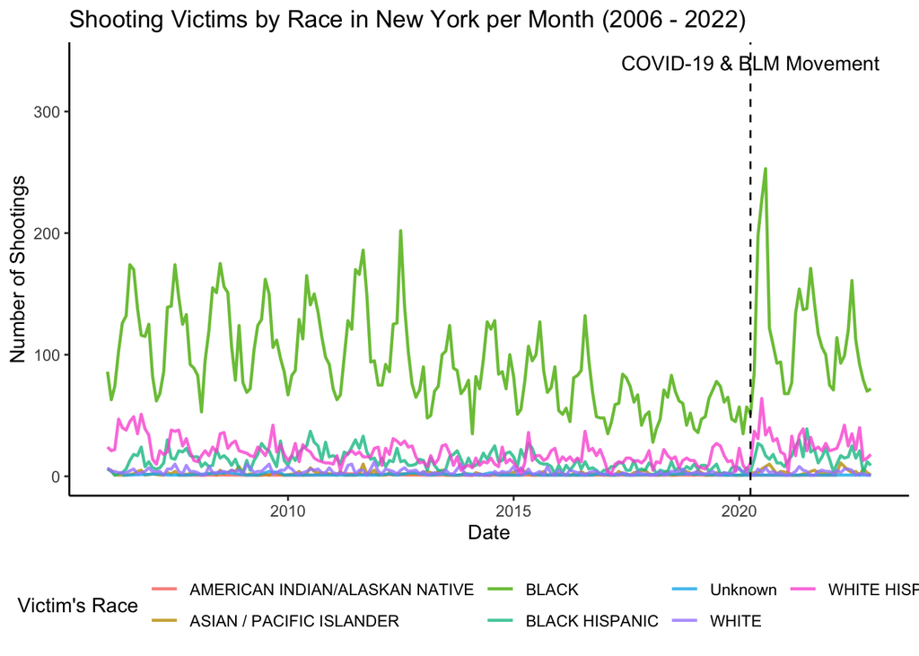

```r
plot_ShootingVictimsByRace <- nypd_sorted %>%
  mutate(Month = floor_date(Date, "month")) %>%
  group_by(Month, VicRace) %>%
  summarize(Count = n()) %>%
  ggplot(aes(x = Month, y = Count, color = VicRace)) +
  geom_line(linewidth = 0.8, alpha = 0.8) +
  geom_vline(xintercept = ymd('2020-04-01'), linetype = "dashed") +
  annotate(geom="text", x = ymd('2020-04-01'), y = 340, label="COVID-19 & BLM Movement") +
  labs(title = "Shooting Victims by Race in New York per Month (2006 - 2022)",
       x = "Date",
       y = "Number of Shootings",
       color = "Victim's Race") +
  theme_classic() +
  theme(legend.position = "bottom")

plot_ShootingPerpetratorsByRace <- nypd_sorted %>%
  mutate(Month = floor_date(Date, "month")) %>%
  group_by(Month, PerpRace) %>%
  summarize(Count = n()) %>%
  ggplot(aes(x = Month, y = Count, color = PerpRace)) +
  geom_line(linewidth = 0.8, alpha = 0.8) +
  geom_vline(xintercept = ymd('2020-04-01'), linetype = "dashed") +
  annotate(geom="text", x = ymd('2020-04-01'), y = 340, label="COVID-19 & BLM Movement") +
  labs(title = "Shooting Perpetrators by Race in New York per Month (2006 - 2022)",
       x = "Date",
       y = "Number of Shootings",
       color = "Perpetrator's Race") +
  theme_classic() +
  theme(legend.position = "bottom")

df <- nypd_sorted %>%
  mutate(Month = floor_date(Date, "month")) %>%
  group_by(Month) %>%
  summarize(Overall = n(),
            VicWhiteHispanic = sum(VicRace == "WHITE HISPANIC"),
            VicBlack = sum(VicRace == "BLACK"),
            VicBlackHispanic = sum(VicRace == "BLACK HISPANIC"),
            VicWhite = sum(VicRace == "WHITE"),
            VicAsianPacificIslander =
              sum(VicRace == "ASIAN / PACIFIC ISLANDER"),
            VicNativeAmericanNativeAlaskan =
              sum(VicRace == "AMERICAN INDIAN/ALASKAN NATIVE")) %>%
  mutate(BeforePandemic = (Month < ymd("2020-04-01")))

df_before <- filter(df, BeforePandemic == TRUE)
df_after <- filter(df, BeforePandemic == FALSE)

plot_ShootingVictimsByRace
```

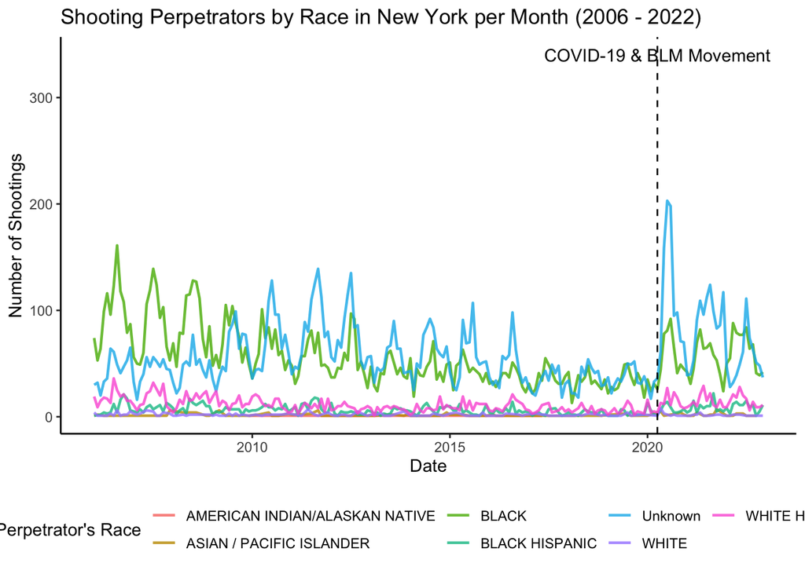

```r
plot_ShootingPerpetratorsByRace
```

Here, I want to go even further ragarding the victims race. Let’s compare the percentage of victims from different racial groups before and after that spring. Here, we can also use linear regression models to visualize the trend, and let’s see what happens.

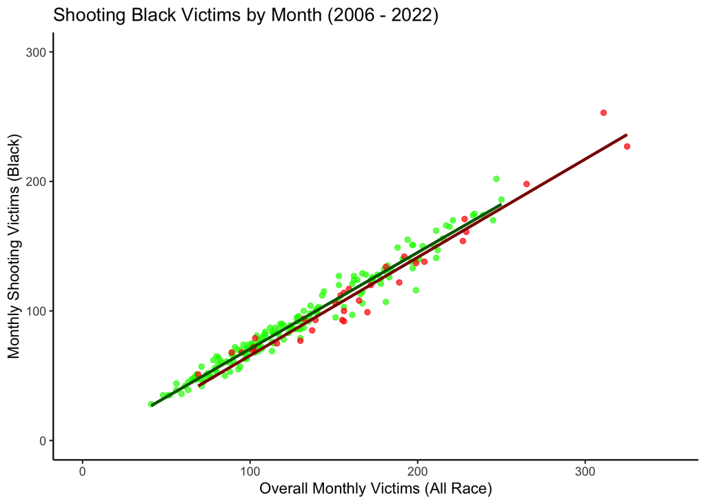

```r
plot_MonthlyShootingBlackVictims <- df %>%
  filter(BeforePandemic == TRUE) %>%
  ggplot() +
  geom_point(data = df_before, aes(y = VicBlack, x = Overall), color="green", alpha=0.7) +
  geom_point(data = df_after, aes(y = VicBlack, x = Overall), color="red", alpha=0.7) +
  geom_smooth(data = df_before,
              aes(y = VicBlack, x = Overall),
              method = "lm",
              se = FALSE,
              color="darkgreen",
              alpha=0.7) +
  geom_smooth(data = df_after,
              aes(y = VicBlack, x = Overall),
              method = "lm",
              se = FALSE,
              color="darkred",
              alpha=0.7) +
  scale_y_continuous(limits = c(0, 300)) +
  scale_x_continuous(limits = c(0, 350)) +
  theme_classic() +
  labs(title = "Shooting Black Victims by Month (2006 - 2022)",
       x = "Overall Monthly Victims (All Race)",
       y = "Monthly Shooting Victims (Black)",
       color = "Victim's Race")
plot_MonthlyShootingBlackVictims
```

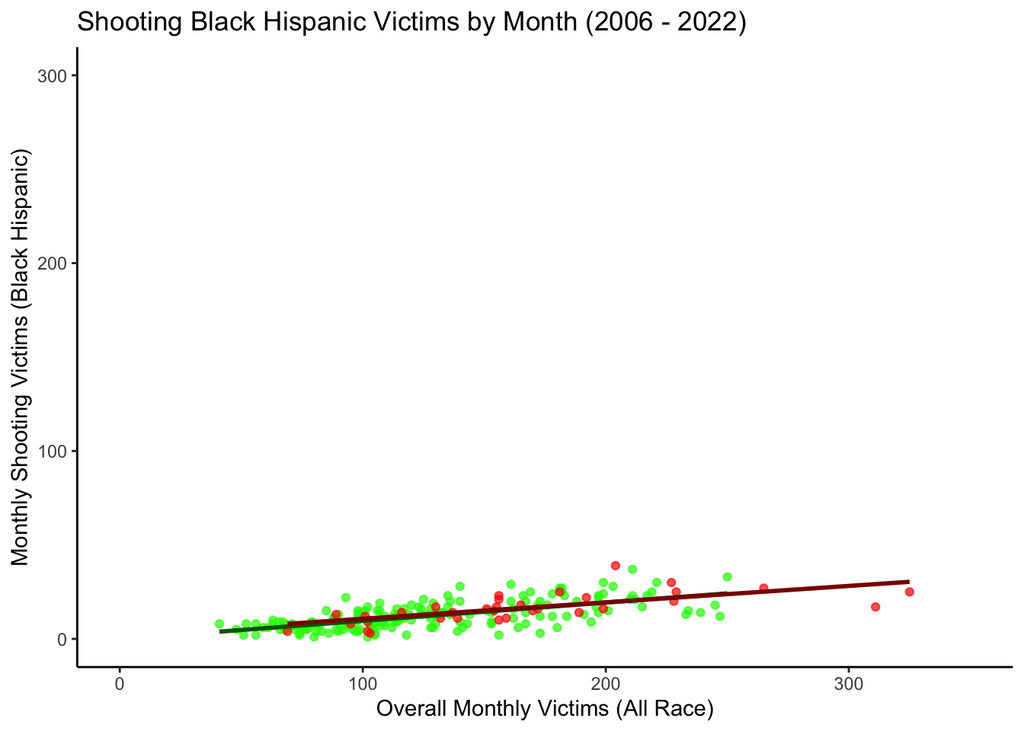

```r
plot_MonthlyShootingBlackHispanicVictims <- df %>%
  filter(BeforePandemic == TRUE) %>%
  ggplot() +
  geom_point(data = df_before, aes(y = VicBlackHispanic, x = Overall), color="green", alpha=0.7) +
  geom_point(data = df_after, aes(y = VicBlackHispanic, x = Overall), color="red", alpha=0.7) +
  geom_smooth(data = df_before,
              aes(y = VicBlackHispanic, x = Overall),
              method = "lm",
              se = FALSE,
              color="darkgreen",
              alpha=0.7) +
  geom_smooth(data = df_after,
              aes(y = VicBlackHispanic, x = Overall),
              method = "lm",
              se = FALSE,
              color="darkred",
              alpha=0.7) +
  scale_y_continuous(limits = c(0, 300)) +
  scale_x_continuous(limits = c(0, 350)) +
  theme_classic() +
  labs(title = "Shooting Black Hispanic Victims by Month (2006 - 2022)",
       x = "Overall Monthly Victims (All Race)",
       y = "Monthly Shooting Victims (Black Hispanic)",
       color = "Victim's Race")
plot_MonthlyShootingBlackHispanicVictims
```

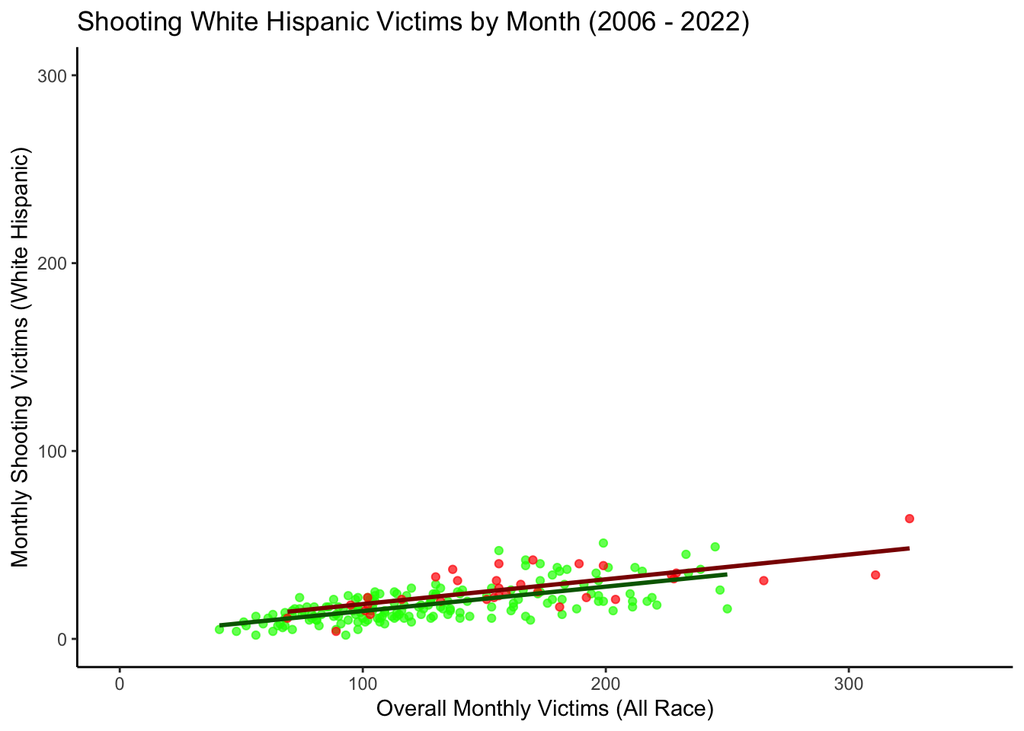

```r
plot_MonthlyShootingWhiteHispanicVictims <- df %>%
  filter(BeforePandemic == TRUE) %>%
  ggplot() +
  geom_point(data = df_before, aes(y = VicWhiteHispanic, x = Overall), color="green", alpha=0.7) +
  geom_point(data = df_after, aes(y = VicWhiteHispanic, x = Overall), color="red", alpha=0.7) +
  geom_smooth(data = df_before,
              aes(y = VicWhiteHispanic, x = Overall),
              method = "lm",
              se = FALSE,
              color="darkgreen",
              alpha=0.7) +
  geom_smooth(data = df_after,
              aes(y = VicWhiteHispanic, x = Overall),
              method = "lm",
              se = FALSE,
              color="darkred",
              alpha=0.7) +
  scale_y_continuous(limits = c(0, 300)) +
  scale_x_continuous(limits = c(0, 350)) +
  theme_classic() +
  labs(title = "Shooting White Hispanic Victims by Month (2006 - 2022)",
       x = "Overall Monthly Victims (All Race)",
       y = "Monthly Shooting Victims (White Hispanic)",
       color = "Victim's Race")
plot_MonthlyShootingWhiteHispanicVictims
```

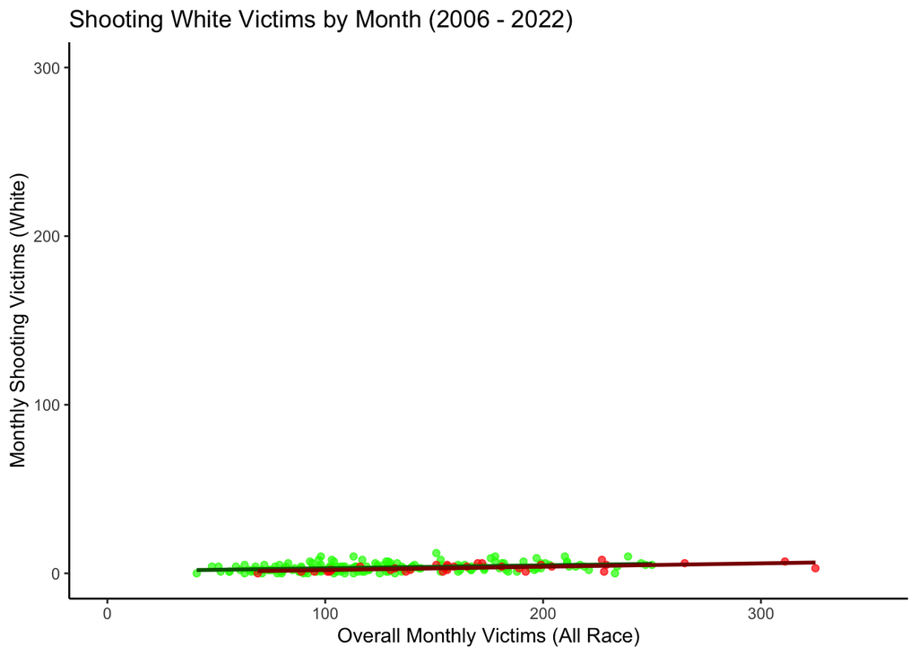

```r
plot_MonthlyShootingWhiteVictims <- df %>%
  filter(BeforePandemic == TRUE) %>%
  ggplot() +
  geom_point(data = df_before, aes(y = VicWhite, x = Overall), color="green", alpha=0.7) +
  geom_point(data = df_after, aes(y = VicWhite, x = Overall), color="red", alpha=0.7) +
  geom_smooth(data = df_before,
              aes(y = VicWhite, x = Overall),
              method = "lm",
              se = FALSE,
              color="darkgreen",
              alpha=0.7) +
  geom_smooth(data = df_after,
              aes(y = VicWhite, x = Overall),
              method = "lm",
              se = FALSE,
              color="darkred",
              alpha=0.7) +
  scale_y_continuous(limits = c(0, 300)) +
  scale_x_continuous(limits = c(0, 350)) +
  theme_classic() +
  labs(title = "Shooting White Victims by Month (2006 - 2022)",
       x = "Overall Monthly Victims (All Race)",
       y = "Monthly Shooting Victims (White)",
       color = "Victim's Race")
plot_MonthlyShootingWhiteVictims
```

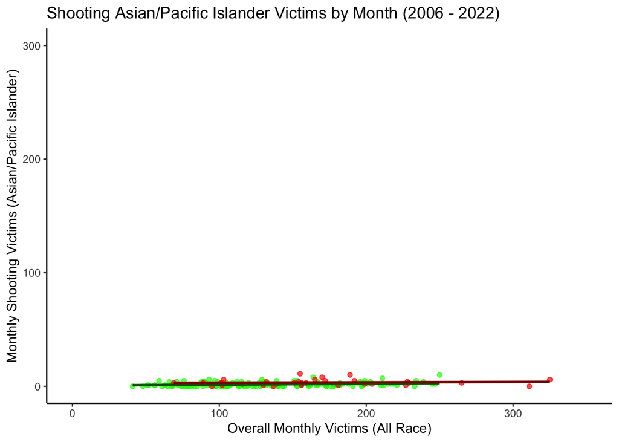

```r
plot_MonthlyShootingAsianPacificIslanderVictims <- df %>%
  filter(BeforePandemic == TRUE) %>%
  ggplot() +
  geom_point(data = df_before, aes(y = VicAsianPacificIslander, x = Overall), color="green", alpha=0.7) +
  geom_point(data = df_after, aes(y = VicAsianPacificIslander, x = Overall), color="red", alpha=0.7) +
  geom_smooth(data = df_before,
              aes(y = VicAsianPacificIslander, x = Overall),
              method = "lm",
              se = FALSE,
              color="darkgreen",
              alpha=0.7) +
  geom_smooth(data = df_after,
              aes(y = VicAsianPacificIslander, x = Overall),
              method = "lm",
              se = FALSE,
              color="darkred",
              alpha=0.7) +
  scale_y_continuous(limits = c(0, 300)) +
  scale_x_continuous(limits = c(0, 350)) +
  theme_classic() +
  labs(title = "Shooting Asian/Pacific Islander Victims by Month (2006 - 2022)",
       x = "Overall Monthly Victims (All Race)",
       y = "Monthly Shooting Victims (Asian/Pacific Islander)",
       color = "Victim's Race")
plot_MonthlyShootingAsianPacificIslanderVictims
```

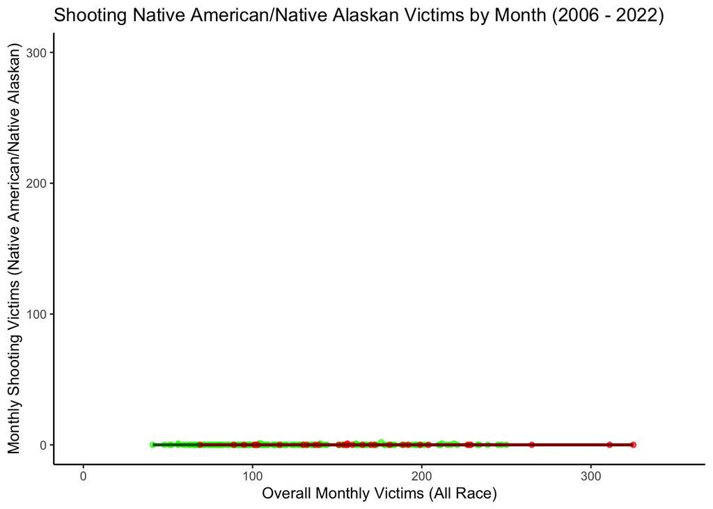

```r
plot_MonthlyShootingNativeAmericanNativeAlaskanVictims <- df %>%
  filter(BeforePandemic == TRUE) %>%
  ggplot() +
  geom_point(data = df_before, aes(y = VicNativeAmericanNativeAlaskan, x = Overall), color="green", alpha=0.7) +
  geom_point(data = df_after, aes(y = VicNativeAmericanNativeAlaskan, x = Overall), color="red", alpha=0.7) +
  geom_smooth(data = df_before,
              aes(y = VicNativeAmericanNativeAlaskan, x = Overall),
              method = "lm",
              se = FALSE,
              color="darkgreen",
              alpha=0.7) +
  geom_smooth(data = df_after,
              aes(y = VicNativeAmericanNativeAlaskan, x = Overall),
              method = "lm",
              se = FALSE,
              color="darkred",
              alpha=0.7) +
  scale_y_continuous(limits = c(0, 300)) +
  scale_x_continuous(limits = c(0, 350)) +
  theme_classic() +
  labs(title = "Shooting Native American/Native Alaskan Victims by Month (2006 - 2022)",
       x = "Overall Monthly Victims (All Race)",
       y = "Monthly Shooting Victims (Native American/Native Alaskan)",
       color = "Victim's Race")
plot_MonthlyShootingNativeAmericanNativeAlaskanVictims
```

Please note that every **green** point in the **Shooting Victims by Month** graphs for each Race represents the observed data **before** the COVID-19 Pandemic/BLM Movement, whereas every **red** point in the chart represents the data **after** the Pandemic.

Whereas the points represent the actual observed data, the **solid lines** drawn over observed data points in those graphs show the approximate prediction from the linear regression models.

We can see no significant difference between before and after the Pandemic in any graphs for any race.

The racial proportions stayed consistent across all groups - Black, White, Black Hispanic, White Hispanic, Native American or Native Alaskan, and Asian or Pacific Islander.

##### Plotting By Sex

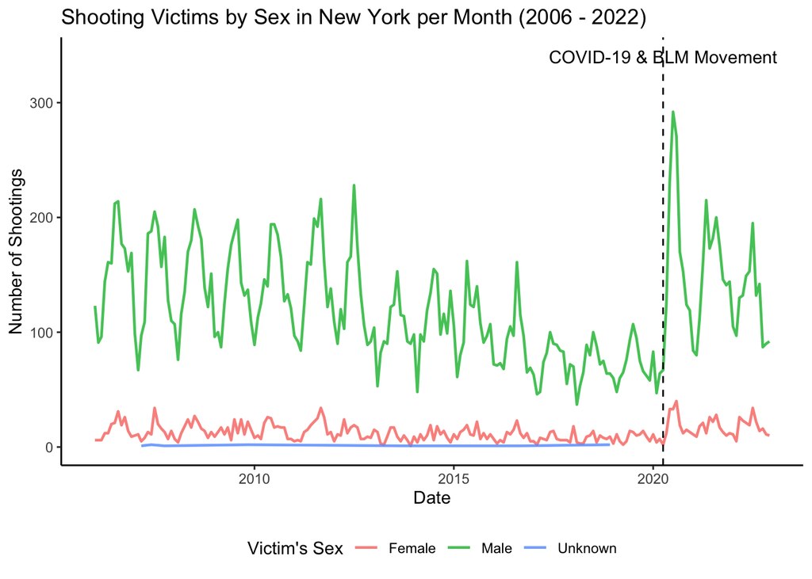

```r
plot_ShootingVictimsBySex <- nypd_sorted %>%
  mutate(Month = floor_date(Date, "month")) %>%
  group_by(Month, VicSex) %>%
  summarize(Count = n()) %>%
  ggplot(aes(x = Month, y = Count, color = VicSex)) +
  geom_line(linewidth = 0.8, alpha = 0.8) +
  geom_vline(xintercept = ymd('2020-04-01'), linetype = "dashed") +
  annotate(geom="text", x = ymd('2020-04-01'), y = 340, label="COVID-19 & BLM Movement") +
  labs(title = "Shooting Victims by Sex in New York per Month (2006 - 2022)",
       x = "Date",
       y = "Number of Shootings",
       color = "Victim's Sex") +
  theme_classic() +
  theme(legend.position = "bottom")

plot_ShootingPerpetratorsBySex <- nypd_sorted %>%
  mutate(Month = floor_date(Date, "month")) %>%
  group_by(Month, PerpSex) %>%
  summarize(Count = n()) %>%
  ggplot(aes(x = Month, y = Count, color = PerpSex)) +
  geom_line(linewidth = 0.8, alpha = 0.8) +
  geom_vline(xintercept = ymd('2020-04-01'), linetype = "dashed") +
  annotate(geom="text", x = ymd('2020-04-01'), y = 340, label="COVID-19 & BLM Movement") +
  labs(title = "Shooting Perpetrators by Sex in New York per Month (2006 - 2022)",
       x = "Date",
       y = "Number of Shootings",
       color = "Perpetrator's Sex") +
  theme_classic() +
  theme(legend.position = "bottom")

df <- nypd_sorted %>%
  mutate(Month = floor_date(Date, "month")) %>%
  group_by(Month) %>%
  summarize(Overall = n(),
            VicFemale = sum(VicSex == "Female"),
            VicMale = sum(VicSex == "Male")) %>%
  mutate(BeforePandemic = (Month < ymd("2020-04-01")))

df_before <- filter(df, BeforePandemic == TRUE)
df_after <- filter(df, BeforePandemic == FALSE)

plot_MonthlyShootingFemaleVictims <- df %>%
  filter(BeforePandemic == TRUE) %>%
  ggplot() +
  geom_point(data = df_before, aes(y = VicFemale, x = Overall), color="green", alpha=0.7) +
  geom_point(data = df_after, aes(y = VicFemale, x = Overall), color="red", alpha=0.7) +
  geom_smooth(data = df_before,
              aes(y = VicFemale, x = Overall),
              method = "lm",
              se = FALSE,
              color="darkgreen",
              alpha=0.7) +
  geom_smooth(data = df_after,
              aes(y = VicFemale, x = Overall),
              method = "lm",
              se = FALSE,
              color="darkred",
              alpha=0.7) +
  scale_y_continuous(limits = c(0, 300)) +
  scale_x_continuous(limits = c(0, 350)) +
  theme_classic() +
  labs(title = "Shooting Female Victims by Month (2006 - 2022)",
       x = "Overall Monthly Victims (All Sex)",
       y = "Monthly Shooting Victims (Female)",
       color = "Victim's Sex")

plot_MonthlyShootingMaleVictims <- df %>%
  filter(BeforePandemic == TRUE) %>%
  ggplot() +
  geom_point(data = df_before, aes(y = VicMale, x = Overall), color="green", alpha=0.7) +
  geom_point(data = df_after, aes(y = VicMale, x = Overall), color="red", alpha=0.7) +
  geom_smooth(data = df_before,
              aes(y = VicMale, x = Overall),
              method = "lm",
              se = FALSE,
              color="darkgreen",
              alpha=0.7) +
  geom_smooth(data = df_after,
              aes(y = VicMale, x = Overall),
              method = "lm",
              se = FALSE,
              color="darkred",
              alpha=0.7) +
  scale_y_continuous(limits = c(0, 300)) +
  scale_x_continuous(limits = c(0, 350)) +
  theme_classic() +
  labs(title = "Shooting Male Victims by Month (2006 - 2022)",
       x = "Overall Monthly Victims (All Sex)",
       y = "Monthly Shooting Victims (Male)",
       color = "Victim's Sex")

plot_ShootingVictimsBySex
```

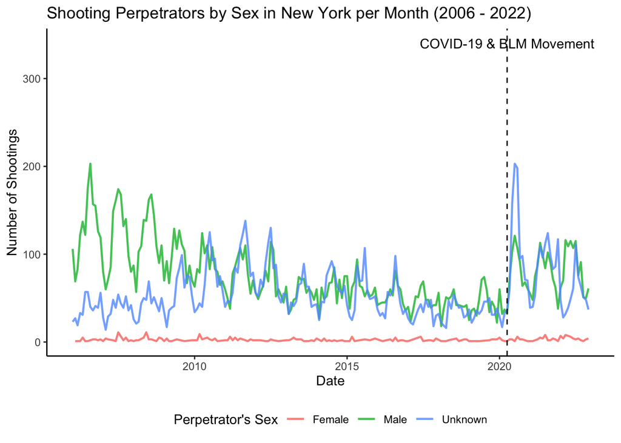

```r
plot_ShootingPerpetratorsBySex
```

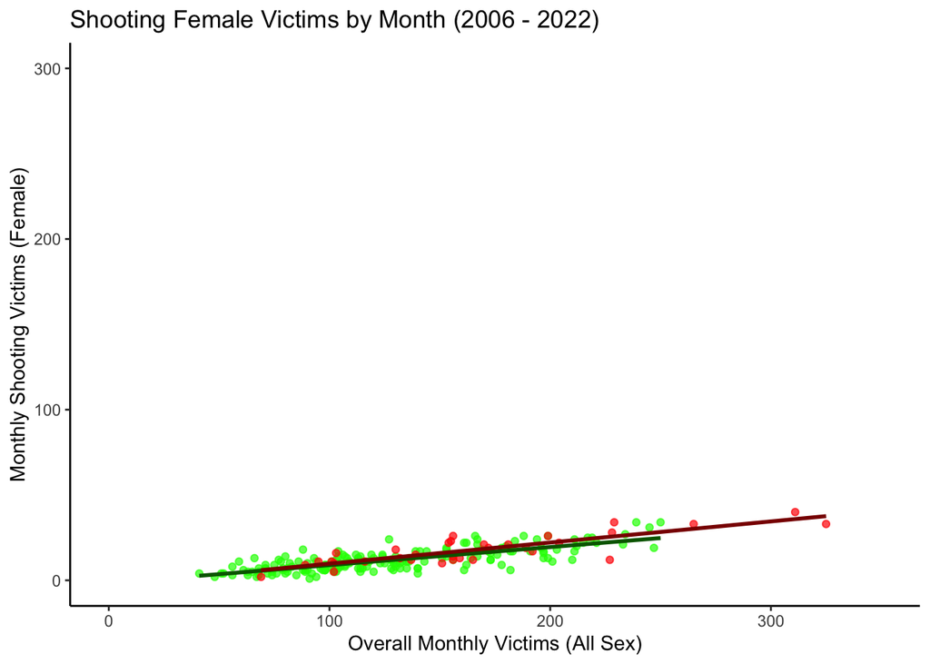

```r
plot_MonthlyShootingFemaleVictims
```

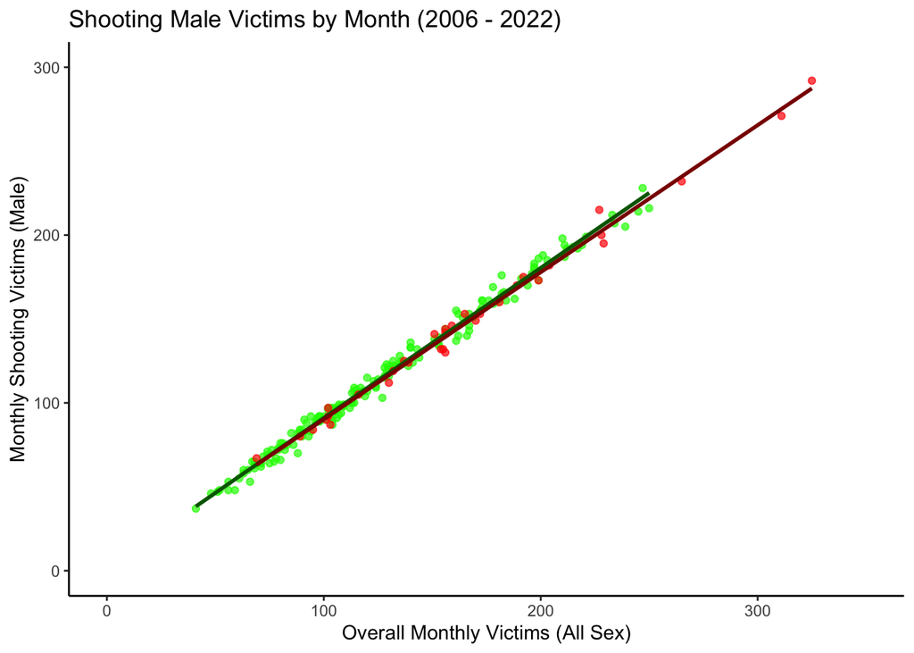

```r
plot_MonthlyShootingMaleVictims
```

Like the previous section for Race, every **green** point in the **Shooting Victims by Month** graphs for each Sex represents the observed data **before** the COVID-19 Pandemic/BLM Movement. In contrast, every **red** point in the chart represents the data **after** the Pandemic.

Whereas the points represent the actual observed data, the **solid lines** drawn over observed data points in those graphs show the approximate prediction from the linear regression models.

### Thoughts about the Possibility of the Root Cause

I have found that the NYPD Shooting Incident Data used in this analysis does not indicate that any particular factor rooted in a specific race or sex is responsible for the surge in New York shootings.

Instead, other factors (Economic Hardship, Mental Health Issues, or even Police Resources Shortage) may be the cause; thus, a larger-scale analysis that combines the data used in this analysis and other data is required.

## Conclusion

In this report, I demonstrated how we can import, tidy, visualize, and analyze open data available from the government site in a reproducible manner. I found the reproducibility possible but acknowledged that fundamental knowledge, basic skills, and meticulous implementations are necessary.

Speaking of the findings from the data analysis, I have found nothing significant that could be attributed to the spike in the NY shootings in May 2020 from any of the attributes of victims and perpetrators, which left us a big question again – if the issue is not rooted in racial matters, to what can we attribute the pronounced rise in shootings?

Regrettably, I do not possess a definitive answer. It is plausible to hypothesize that a confluence of factors is at play, such as economic downturns, challenges in mental health, or a diminution of police resources during that particular period due to unforeseen circumstances.

Further research must be conducted on this matter. I hope comprehensive analyses of extensive datasets in the future will elucidate this problem.

## Bias Identification

Eliminating bias in data analysis is challenging; this report is no exception.

The U.S. Census breaks down race into six main categories: White, Black or African American, Native American or Native Alaskan, Asian, Native Hawaiian or other Pacific Islander, and Other. This dataset on NYC shootings has six categories, too, but they don’t exactly line up with the Census. While some races like Black, White, and Native American or Native Alaskan are consistent, this NYPD dataset introduces categories like “White Hispanic” and “Black Hispanic,” combines Asians and Pacific Islanders into one group, leaves out the “Other” class, and adds an “Unknown” label.

This brings up some questions about the classifications. How do they distinguish “White Hispanic” from just “White” in terms of race? Why are Asians, despite being such a diverse group with over 4 billion people, all grouped under one category? And where do mixed-race individuals fit in?

Whether we’re looking at the Census data or the NYPD data, it seems overly simplistic to reduce race to just these six categories.

Additionally, you might be wondering: Who set these racial categories at the scene of the incident? Was it based on how the individual identified themselves? If the person is no longer alive, who decides their race? Was it determined by onlookers? What standards were used? It’s clear that this dataset has its biases. Thus, as this analysis is based on data with built-in biases influencing our conclusions, we must keep that perspective.